# Simulation

Statistical Computing, 36-350

Monday July 22, 2019

# Last week: Tidyverse II: `tidyr`

- `tidyr` is a package for manipulating the structure of data frames
- `gather()`: make wide data longer
- `spread()`: make long data wider
- `unite()` and `separate()`: combine or split columns
- `dplyr` has advanced functionality that mirrors SQL
- `group_by()`: create groups of rows according to a condition
- `summarize()`: apply computations across groups of rows
- `*_join()` where `*` = `inner`, `left`, `right`, or `full`: join two data frames together according to common values in certain columns, and `*` indicates how many rows to keep

# Part I

*Simulation basics*

# Why simulate?

R gives us unique access to great simulation tools (unique compared to other languages). Why simulate? Welcome to the 21st century! Two reasons:

- Often, simulations can be easier than hand calculations
- Often, simulations can be made more realistic than hand calculations

# Sampling from a given vector

To sample from a given vector, use `sample()`

```r
sample(x = letters, size = 10) # Without replacement, the default
```

```
##  [1] "f" "t" "q" "p" "a" "z" "g" "j" "w" "n"
```

```r
sample(x = c(0,1), size = 10, replace = TRUE) # With replacement
```

```
##  [1] 0 1 0 0 1 0 0 0 1 0
```

```r
sample(x = 10) # Arguments set as x=1:10, size=10, replace=FALSE
```

```
##  [1]  5  8  4  7  2  3  1  6  9 10
```

# Random number generation

To sample from a normal distribution, we have the utility functions:

- `rnorm()`: generate normal random variables
- `pnorm()`: normal distribution function, $\Phi(x)=P(Z \leq x)$
- `dnorm()`: normal density function, $\phi(x)= \Phi'(x)$
- `qnorm()`: normal quantile function, $q(y)=\Phi^{-1}(y)$, i.e., $\Phi(q(y))=y$

Replace “norm” with the name of another distribution, all the same functions apply. E.g., “t”, “exp”, “gamma”, “chisq”, “binom”, “pois”, etc.

# Random number examples

Standard normal random variables (mean 0 and variance 1)

```r
n <- 200
z <- rnorm(n, mean = 0, sd = 1) # These are the defaults for mean, sd
mean(z)  # Check: sample mean is approximately 0
```

```
## [1] 0.006089724
```

```r
var(z)   # Check: sample variance is approximately 1
```

```
## [1] 1.092156
```

# Estimated distribution function

To compute empirical cumulative distribution function (ECDF)—the standard estimator of the cumulative distribution function—use `ecdf()`

```r
library(tidyverse)
ecdf_fun <- ecdf(z) # Create the ECDF
class(ecdf_fun) # It's a function!
```

```
## [1] "ecdf"     "stepfun"  "function"
```

```r
ecdf_fun(0)
```

```
## [1] 0.495
```

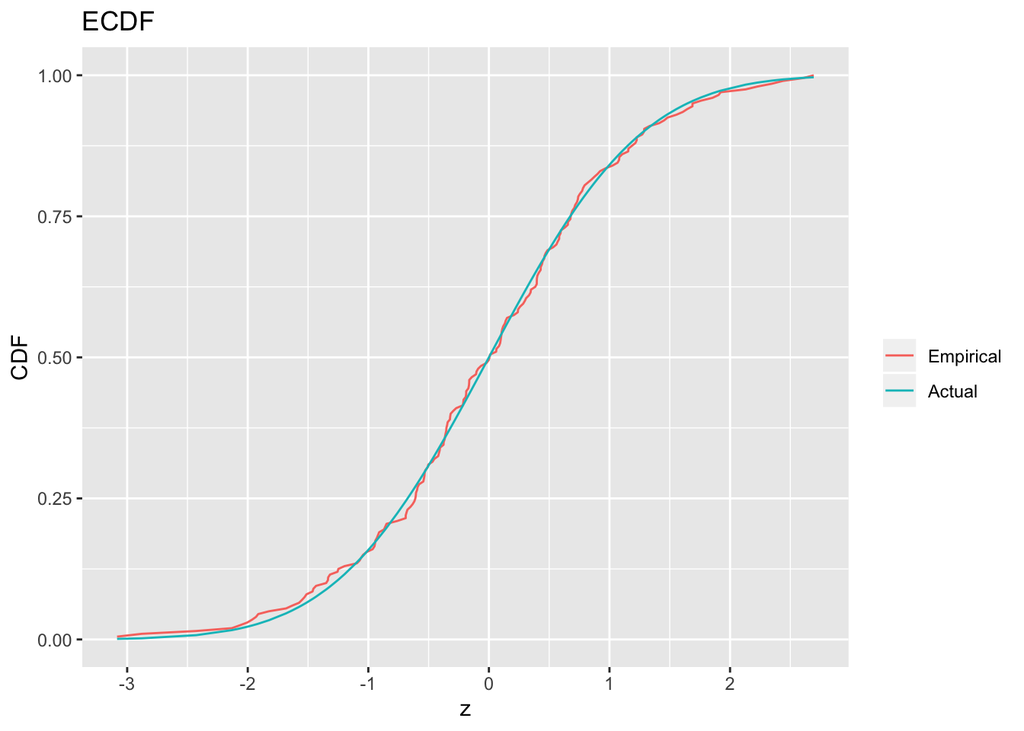

```r
# We can plot it

gaussian_data <- data.frame(z = sort(z)) %>%
  mutate(ecdf = ecdf_fun(z),
         true = pnorm(z))

gaussian_data_lines <- gaussian_data %>%
  gather("line", "value",
         ecdf, true, -z) %>%
  mutate(line = forcats::fct_recode(line,
                                    Empirical = "ecdf",
                                    Actual = "true"))

ggplot(gaussian_data_lines, aes(x = z, y = value, color = line)) +
  geom_line() +
  labs(y = "CDF",
       title = "ECDF",
       color = "")
```

# Estimated density function

To compute histogram —a basic estimator of the density based on binning—use `hist()`

```r
hist_obj <- hist(z, breaks = 30, plot = FALSE) # base R function
class(hist_obj) # It's a list
```

```
## [1] "histogram"
```

```r
hist_obj$breaks # These are the break points that were used
```

```
##  [1] -3.2 -3.0 -2.8 -2.6 -2.4 -2.2 -2.0 -1.8 -1.6 -1.4 -1.2 -1.0 -0.8 -0.6
## [15] -0.4 -0.2  0.0  0.2  0.4  0.6  0.8  1.0  1.2  1.4  1.6  1.8  2.0  2.2
## [29]  2.4  2.6  2.8
```

```r
hist_obj$density # These are the estimated probabilities
```

```
##  [1] 0.025 0.025 0.000 0.025 0.000 0.075 0.100 0.050 0.175 0.150 0.150
## [12] 0.250 0.275 0.400 0.425 0.350 0.375 0.350 0.425 0.400 0.150 0.200
## [23] 0.175 0.100 0.125 0.075 0.025 0.050 0.025 0.050
```

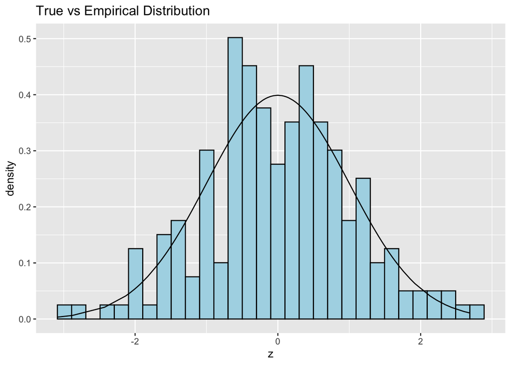

```r
# We can plot it
gaussian_data <- gaussian_data %>%
  mutate(PDF = dnorm(z))

ggplot(gaussian_data, aes(x = z, y = ..density..)) +
  geom_histogram(bins = 30,
                 fill = "lightblue",
                 col = "black") +
  geom_line(aes(y = PDF)) +
  labs(title = "True vs Empirical Distribution")
```

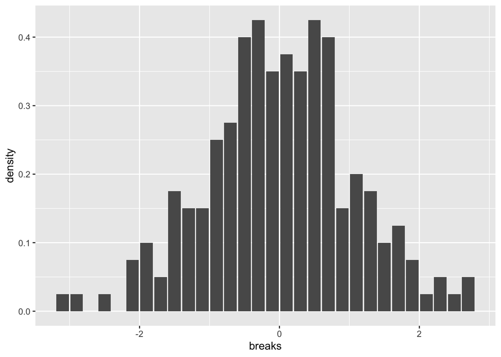

```r
hist_data <- data.frame(breaks = hist_obj$breaks[1:(length(hist_obj$breaks) - 1)] + .1,
                        density = hist_obj$density)

ggplot(hist_data, aes(x = breaks, y = density)) +
  geom_histogram(stat = "identity")
```

# Tangent on estimation (did you know?)

Interesting statistical facts:

- When you have lots of data, the empirical distribution function will always be close to the actual distribution function (Glivenko-Cantelli, “Fundamental Theorem of Statistics”)
- When you have lots of data, the histogram estimator is not always close to the density function, only when the underlying density is quite smooth
- In general, density estimation is tricky, there are many estimators beyond histograms worth studying/knowing about; e.g., `density()` uses a kernel density estimator (gives a function) and you’ve already seen `geom_density`

# Part II

*Pseudorandomness and seeds*

# Same function call, different results

Not surprisingly, we get different draws each time we call `rnorm()`

```r
mean(rnorm(n))
```

```
## [1] -0.06128671
```

```r
mean(rnorm(n))
```

```
## [1] 0.06798459
```

```r
mean(rnorm(n))
```

```
## [1] 0.0256657
```

```r
mean(rnorm(n))
```

```
## [1] -0.07122027
```

# Is it really random?

Random numbers generated in R (in any language) are not “truly” random; they are what we call **pseudorandom**

- These are numbers generated by computer algorithms that very closely mimick “truly” random numbers
- The study of such algorithms is an interesting research area in its own right!
- The default algorithm in R (and in nearly all software languages) is called the “Mersenne Twister”
- Type `?Random` in your R console to read more about this (and to read how to change the algorithm used for pseudorandom number generation, which you should never really have to do, by the way)

# Setting the random seed

All pseudorandom number generators depend on what is called a **seed** value

- This puts the random number generator in a well-defined “state”, so that the numbers it generates, from then on, will be reproducible
- The seed is just an integer, and can be set with `set.seed()`
- The reason we set it: so that when someone else runs our simulation code, they can see the same—albeit, still random—results that we do

# Seed examples

```r
# Getting the same 5 random normals over and over
set.seed(0); rnorm(5)
```

```
## [1]  1.2629543 -0.3262334  1.3297993  1.2724293  0.4146414
```

```r
set.seed(0); rnorm(5)
```

```
## [1]  1.2629543 -0.3262334  1.3297993  1.2724293  0.4146414
```

```r
set.seed(0); rnorm(5)
```

```
## [1]  1.2629543 -0.3262334  1.3297993  1.2724293  0.4146414
```

```r
# Different seeds, different numbers
set.seed(1); rnorm(5)
```

```
## [1] -0.6264538  0.1836433 -0.8356286  1.5952808  0.3295078
```

```r
set.seed(2); rnorm(5)
```

```
## [1] -0.89691455  0.18484918  1.58784533 -1.13037567 -0.08025176
```

```r
set.seed(3); rnorm(5)
```

```
## [1] -0.9619334 -0.2925257  0.2587882 -1.1521319  0.1957828
```

```r
# Each time the seed is set, the same sequence follows (indefinitely)
set.seed(0); rnorm(3); rnorm(2); rnorm(1)
```

```
## [1]  1.2629543 -0.3262334  1.3297993
```

```
## [1] 1.2724293 0.4146414
```

```
## [1] -1.53995
```

```r
set.seed(0); rnorm(3); rnorm(2); rnorm(1)
```

```
## [1]  1.2629543 -0.3262334  1.3297993
```

```
## [1] 1.2724293 0.4146414
```

```
## [1] -1.53995
```

```r
set.seed(0); rnorm(3); rnorm(2); rnorm(1)
```

```
## [1]  1.2629543 -0.3262334  1.3297993
```

```
## [1] 1.2724293 0.4146414
```

```
## [1] -1.53995
```

# Part III

*Iteration and simulation*

# Drug effect model

- Let’s start with a motivating example: suppose we had a model for the way a drug affected certain patients
- All patients will undergo chemotherapy. We believe those who aren’t given the drug experience a reduction in tumor size of percentage
  $$X_{\mathrm{no\,drug}} \sim 100 \cdot \mathrm{Exp}(\mathrm{mean}=R),
  \;\;\; R \sim \mathrm{Unif}(0,1)$$
- And those who were given the drug experience a reduction in tumor size of percentage
  $$X_{\mathrm{drug}} \sim 100 \cdot \mathrm{Exp}(\mathrm{mean}=2)$$
  (Here $\mathrm{Exp}$ denotes the exponential distribution, and $\mathrm{Unif}$ the uniform distribution)

# What would you do?

What would you do if you had such a model, and your scientist collaborators asked you: *how many patients would we need to have in each group (drug, no drug), in order to reliably see that the average reduction in tumor size is large?*

- Answer used to be: get out your pen and paper, make some approximations
- Answer is now: simulate from the model, no approximations required!

# So, let’s simulate!

```r
# Simulate, supposing 60 subjects in each group
set.seed(0)
n <- 60
mu_drug <- 2
mu_nodrug <- runif(n, min = 0, max = 1)
x_drug <- 100 * rexp(n, rate = 1/mu_drug)
x_nodrug <- 100 * rexp(n, rate = 1/mu_nodrug)
```

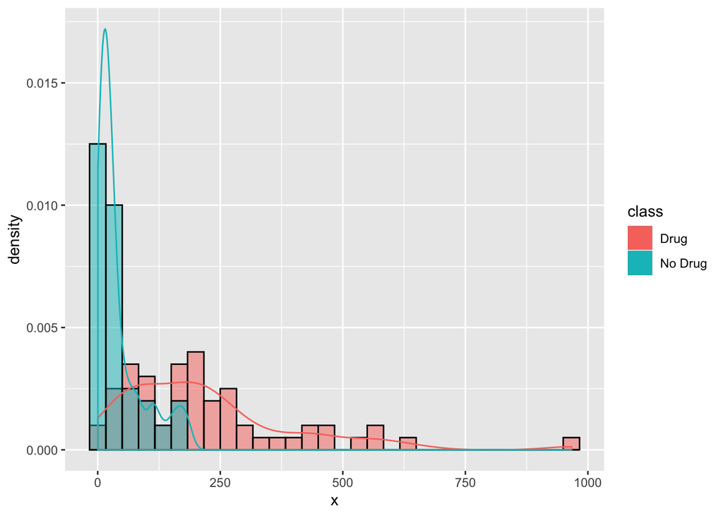

```r
sim_data <- data.frame(x = c(x_drug, x_nodrug),
                       class = factor(rep(c("Drug","No Drug"), each = 60)))

sim_data %>%
  ggplot(aes(x = x, y = ..density.., color = class)) +
  geom_histogram(aes(fill = class),
                 alpha = .5, color = "black",
                 position = "identity") +
  geom_density(aes(color = class))
```

# Kernel Density Estimates

- When we use `geom_density` we are really getting a kernel density estimate - which can be thought of as adding little globs of honey centered at each point.
  - Learng more about KDEs in this [interactive presentation](https://mathisonian.github.io/kde/).
- we can change the “spread” of each individual glob of honey, etc

If we just want to calculate the a density function we can change the “spread” by changing the bandwidth (`bw`). For `ggplot` we can access this by using the `stat_density` instead of `geom_density`:

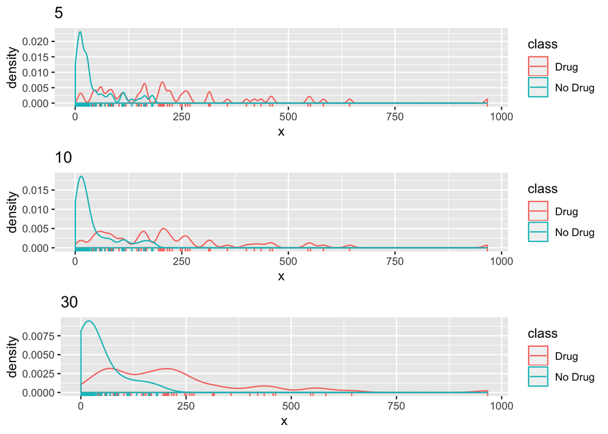

```r
library(gridExtra)

gg_vis <- list()
for (bw in c(5,10,30)) {
  gg_vis[[as.character(bw)]] <- sim_data %>%
  ggplot(aes(x = x, color = class)) +
  geom_density(aes(color = class), bw = bw) +
  geom_rug() +
  labs(title = bw)
}

grid.arrange(grobs = gg_vis, ncol = 1)
```

# Repetition and reproducibility

- One single simulation is not always trustworthy (depends on the situation, of course)
- In general, simulations should be repeated and aggregate results reported—requires iteration!
- To make random number draws reproducible, we must set the seed with `set.seed()`
- More than this, to make simulation results reproducible, we need to follow **good programming practices**
- Gold standard: any time you show a simulation result (a figure, a table, etc.), you have code that can be run (by anyone) to produce exactly the same result

# Iteration and simulation (and functions): good friends

- Writing a **function** to complete a single run of your simulation is often very helpful
- This allows the simulation itself to be intricate (e.g., intricate steps, several simulation parameters), but makes running the simulation simple
- Then you can use **iteration** to run your simulation over and over again
- Good design practice: write another function for this last part (running your simulation many times)

# Code sketch

Consider the code below for a generic simulation. Think about how you would frame this for the drug effect example, which you’ll revisit in lab

```r
# Function to do one simulation run
one_sim <- function(param1, param2 = value2, param3 = value3) {
  # Possibly intricate simulation code goes here
}

# Function to do repeated simulation runs
rep_sim <- function(nreps, param1, param2 = value2,
                   param3 = value3, seed = NULL) {
  # Set the seed, if we need to
  if(!is.null(seed)) set.seed(seed)

  # Run the simulation over and over
  sim_objs <- vector(length = nreps, mode = "list")
  for (r in 1:nreps) {
    sim_objs[r] <- one_sim(param1, param2, param3)
  }

  # Aggregate the results somehow, and then return something
}
```

# Part IV

*Reading in and writing out data*

# Saving results

Sometimes simulations take a long time to run, and we want to save intermediate or final output, for quick reference later

There two different ways of saving things from R (there are more than two, but here are two useful ones):

- `saveRDS()`: allows us to save single R objects (like a vector, matrix, list, etc.), in (say) .rds format. E.g.,

  ```r
  saveRDS(my_mat, file = "my_matrix.rds")
  ```

- `save()`: allows us to save any number of R objects in (say) .rdata format. E.g.,

  ```r
  save(mat_x, mat_y, list_z, file="my_objects.rdata")
  ```

Note: there is a big difference between how these two treat variable names

# Loading results

Corresponding to the two different ways of saving, we have two ways of loading things into R:

- `readRDS()`: allows us to load an object that has been saved by `savedRDS()`, and **assign a new variable name**. E.g.,

  ```r
  my_new_mat <- readRDS("my_matrix.rds")
  ```

- `load()`: allows us to load all objects that have been saved through `save()`, **according to their original variables names**. E.g.,

  ```r
  load("my_objects.rdata")
  ```

# Commentary on R based saving and loading

- `readRDS()`, `saveRDS()`: functions for reading/writing single R objects from/to a file
- `load()`, `save()`: functions for reading/writing any number of R objects from/to a file

Advantage: these can be a lot more memory efficient than other tools

Disadvantage: they’re limited in scope in the sense that they can only communicate with R

# Reading in data from the outside

All along, we’ve already been reading in data from the outside, using:

- `readLines()`: reading in lines of text from a file or webpage; returns vector of strings
- `read.table()`: read in a data table from a file or webpage; returns data frame
- `read.csv()`: like the above, but assumes comma separated data; returns data frame

This week we’ll focus on `read.table()`, `read.csv()` and their counterparts `write.table()`, `write.csv()`, respectively

# `read.table()`, `read.csv()`

Have a table full of data, just not in the R file format? Then `read.table()` is the function for you. It works as in:

- `read.table(file = file.name, sep = " ")`, to read data from a local file on your computer called `file.name`, assuming (say) space separated data
- `read.table(file = webpage_link, sep = "\t")`, to read data from a webpage up at `webpage_link`, assuming (say) tab separated data

The function `read.csv()` is just a shortcut for using `read.table()` with `sep=","`. (But note: these two actually differ on some of the default inputs!)

# Helpful input arguments

- `header`: boolean, TRUE is the first line should be interpreted as column names
- `sep`: string, specifies what separates the entries; empty string “” is interpreted to mean any white space
- `check.names`: boolean, if FALSE, don’t update names of columns to be more `$` friendly
- `stringsAsFactors`: boolean, if FALSE - leave strings a strings (if TRUE converts them to factors)

Other helpful inputs: `skip`, `row.names`, `col.names`. You can read about them in the help file for `read.table()`

# Example of reading in data

```r
shark_attacks <- read.table(
  file="https://raw.githubusercontent.com/benjaminleroy/36-350-summer-data/master/Week2/shark-attacks-clean.csv",
  sep = ",", header = TRUE)
head(shark_attacks)
```

```
##   X  Case.Number       Date       Type   Country              Area
## 1 1 2016.09.18.c 2016-09-18 Unprovoked       USA           Florida
## 2 2 2016.09.18.b 2016-09-18 Unprovoked       USA           Florida
## 3 3 2016.09.18.a 2016-09-18 Unprovoked       USA           Florida
## 4 4   2016.09.17 2016-09-17 Unprovoked AUSTRALIA          Victoria
## 5 5   2016.09.15 2016-09-16 Unprovoked AUSTRALIA          Victoria
## 6 6 2016.09.15.R 2016-09-15       Boat AUSTRALIA Western Australia
##                           Location Activity                   Name Sex Age
## 1 New Smyrna Beach, Volusia County  Surfing                   male   M  24
## 2 New Smyrna Beach, Volusia County  Surfing         Chucky Luciano   M  74
## 3 New Smyrna Beach, Volusia County  Surfing                   male   M  85
## 4                 Thirteenth Beach  Surfing        Rory Angiolella   M  -5
## 5                      Bells Beach  Surfing                   male   M  -5
## 6                          Bunbury  Fishing Occupant: Ben Stratton   U  -5
##                                     Injury  Time   Species
## 1                    Minor injury to thigh 13h00      <NA>
## 2                     Lacerations to hands 11h00      <NA>
## 3                 Lacerations to lower leg 10h43      <NA>
## 4             Struck by fin on chest & leg  <NA>      <NA>
## 5    No injury: Knocked off board by shark  <NA> 2 m shark
## 6 Shark rammed boat. No injury to occupant  <NA>      <NA>
##        Investigator.or.Source Fatal SharkLength
## 1 Orlando Sentinel, 9/19/2016     N          10
## 2 Orlando Sentinel, 9/19/2016     N           9
## 3 Orlando Sentinel, 9/19/2016     N           5
## 4          The Age, 9/18/2016     N           8
## 5          The Age, 9/16/2016     N           9
## 6  West Australian, 9/15/2016     N          10
```

```r
sapply(shark_attacks, class)
```

```
##                      X            Case.Number                   Date
##              "integer"               "factor"               "factor"
##                   Type                Country                   Area
##               "factor"               "factor"               "factor"
##               Location               Activity                   Name
##               "factor"               "factor"               "factor"
##                    Sex                    Age                 Injury
##               "factor"              "integer"               "factor"
##                   Time                Species Investigator.or.Source
##               "factor"               "factor"               "factor"
##                  Fatal            SharkLength
##               "factor"              "integer"
```

# `write.table()`, `write.csv()`

To write a data frame (or matrix) to a text file, use `write.table()` or `write.csv()`. These are the counterparts to `read.table()` and `read.csv()`, and they work as in:

- `write.table(my_df, file = "my_df.txt", sep = " ", quote = FALSE)`, to write `my_df` to the text file “my_df.txt” (to be created in your working directory), with (say) space separation, and no quotes around the entries
- `write.csv(my_df, file="my_df.csv", quote = FALSE)`, to write `my_dat` to the text file “my_df.csv” (to be created in your working directory), with comma separation, and no quotes

Note that `quote = FALSE`, signifying that no quotes should be put around the printed data entries, seems always preferable (default is `quote = TRUE`). Also, setting `row.names = FALSE` and `col.names = FALSE` will disable the printing of row and column names (defaults are `row.names = TRUE` and `col.names = TRUE`)

# Summary

- Running simulations is an integral part of being a statistician in the 21st century
- R provides us with a utility functions for simulations from a wide variety of distributions
- To make your simulation results reproducible, you must set the seed, using `set.seed()`
- There is a natural connection between iteration, functions, and simulations
- Saving and loading results can be done in two formats: rds and rdata formats
- Read in data from a previous R session with `readRDS()`, `load()`
- Read in data from the outside with `read.table()`, `read.csv()`
- Can sometimes be tricky to get arguments right in `read.table()`, `read.csv()`; helps sometimes take a look at the original data files to see their structure